# Beyond Linear Regression: Evaluating Ensemble Learners in Hedonic Housing Price Estimation

- Show All Code
- Hide All Code
- View Source

Author

Hamza Aalaou

Published

April 10, 2026

Abstract

This report details a complete machine learning pipeline applied to the Ames Housing dataset to forecast residential property sale prices. We transition from descriptive analyses of raw housing attributes to a refined dataset addressing structural missingness, multicollinearity, and right-skewed price outliers via Log(1p) transformations. Through PCA and K-Means clustering, distinct abstract spatial and quality typologies (“Market Segments”) were identified. Finally, ensemble frameworks (Random Forest, XGBoost) decisively outperformed regularized linear baselines (LassoCV), demonstrating that non-linear architectures natively capture the multidimensional complexities of hedonic real estate valuation.

# 1 Introduction

## 1.1 Project Goals

The main goal of this project is to predict house sale prices using structural, spatial, and qualitative features. By analyzing a dataset of residential properties encompassing various attributes (such as total square footage, neighborhood, overall quality, and condition), we aim to uncover the underlying patterns that determine a property’s value. This involves exploring correlations between physical characteristics—like living area and basement size—and a property’s sale price. Ultimately, we seek to build robust machine learning models capable of forecasting real estate prices, providing valuable insights for valuation and risk assessment while addressing common data idiosyncrasies like right-skewed pricing distributions and structurally meaningful missing values.

## 1.2 Research Questions

Our primary research question is: - To what extent can the sale price of a property be predicted using its structural, location, and qualitative features?

To thoroughly investigate this, we will explore the following sub-questions:

## 1.3 Related Work

Recent research in quantitative real estate economics and predictive analytics demonstrates that machine learning models can effectively predict market values by capturing complex structural and local data. Studies consistently highlight that core features like Total Square Footage and overall structural quality act as the primary variables in house pricing.

**Key Findings in Domain Literature:** - **Model Performance:** Authors emphasize that ensemble models naturally outperform unregularized linear models by capturing non-linear interactions (e.g., house prices might increase logarithmically relative to certain square foot thresholds, or interact sharply with specific neighborhoods). - **Handling Data Structure:** Research frequently addresses data sparsity in property disclosures. Standard econometric approaches rely on proper missing data treatments (like encoding ‘None’ appropriately for lacking features) and utilizing Log Transformations on dependent variables exhibiting right-skewness to normalize error distributions during regression modeling.

Relevant literature and references informing this approach draw from extensive applications of Hedonic Price Theory and urban real estate modeling methodologies (e.g., standard baseline studies typically covered in datasets like Ames Housing).

# 2 Data

## 2.1 Sources

Our primary dataset was sourced from Kaggle: **House Prices - Advanced Regression Techniques**. The dataset compiles residential property sales in Ames, Iowa, and includes numerous structural, spatial, and qualitative features for each property.

**ImportantData Source Documentation**

The dataset is available at the following URL: https://www.kaggle.com/c/house-prices-advanced-regression-techniques.

## 2.2 Description

The raw dataset contains detailed observations of house sales. After undergoing a rigorous cleaning process—where we handled structurally missing variables, normalized the skewed target variable, and engineered new features—our final dataset provides a robust foundation for building our machine learning models.

**NoteDataset Overview**

- **Number of observations**: 1,460 in training set
- **Number of variables**: 82 columns (after feature engineering)
- **Time period**: Sales occurring between 2006 and 2010.
- **Geographic coverage**: Ames, Iowa, USA.
- **Key variables**: `SalePrice`, `TotalSF`, `OverallQual`, `GrLivArea`, `Neighborhood`, and various property condition ratings.

## 2.3 Loading Data

The following code loads the pre-processed data, which is the result of the `clean_data.py` script we developed. This ensures that our analysis starts with a clean, consistent, and analysis-ready dataset without duplicating code.

```python
"""Loading the cleaned Ames Housing dataset."""

import pandas as pd
from IPython.display import display

# Define the path to the PROCESSED data
processed_data_path = "../data/processed/train_cleaned.csv"

# Load the data
data = pd.read_csv(processed_data_path, skipinitialspace=True)

# Basic data inspection
print(f"Dataset shape: {data.shape[0]} rows × {data.shape[1]} columns")
print(f"\nColumn names: {list(data.columns)}")

# Display first few rows
print("\nFirst 5 rows:")
display(data.head())
```

```
Dataset shape: 1460 rows × 82 columns

Column names: ['Id', 'MSSubClass', 'MSZoning', 'LotFrontage', 'LotArea', 'Street', 'Alley', 'LotShape', 'LandContour', 'Utilities', 'LotConfig', 'LandSlope', 'Neighborhood', 'Condition1', 'Condition2', 'BldgType', 'HouseStyle', 'OverallQual', 'OverallCond', 'YearBuilt', 'YearRemodAdd', 'RoofStyle', …

First 5 rows:
```

|  | Id | MSSubClass | MSZoning | LotFrontage | LotArea | Street | Alley | LotShape | LandContour | Utilities | ... | PoolQC | Fence | MiscFeature | MiscVal | MoSold | YrSold | SaleType | SaleCondition | SalePrice | TotalSF |
| --- | --- | --- | --- | --- | --- | --- | --- | --- | --- | --- | --- | --- | --- | --- | --- | --- | --- | --- | --- | --- | --- |
| 0 | 1 | 60 | RL | 65.0 | 8450 | Pave | NaN | Reg | Lvl | AllPub | ... | NaN | NaN | NaN | 0 | 2 | 2008 | WD | Normal | 12.247699 | 2566 |
| 1 | 2 | 20 | RL | 80.0 | 9600 | Pave | NaN | Reg | Lvl | AllPub | ... | NaN | NaN | NaN | 0 | 5 | 2007 | WD | Normal | 12.109016 | 2524 |
| 2 | 3 | 60 | RL | 68.0 | 11250 | Pave | NaN | IR1 | Lvl | AllPub | ... | NaN | NaN | NaN | 0 | 9 | 2008 | WD | Normal | 12.317171 | 2706 |
| 3 | 4 | 70 | RL | 60.0 | 9550 | Pave | NaN | IR1 | Lvl | AllPub | ... | NaN | NaN | NaN | 0 | 2 | 2006 | WD | Abnorml | 11.849405 | 2473 |
| 4 | 5 | 60 | RL | 84.0 | 14260 | Pave | NaN | IR1 | Lvl | AllPub | ... | NaN | NaN | NaN | 0 | 12 | 2008 | WD | Normal | 12.429220 | 3343 |

5 rows × 82 columns

## 2.4 Wrangling

### 2.4.1 General Transformations

A separate Python script (`src/clean_data.py`) was used to perform all data preprocessing. This approach keeps our reporting document clean and ensures reproducibility. The key steps performed were:

1. **Handling Missingness Scientifically**: Many “missing” values in this dataset denote the systematic absence of a feature rather than data entry errors. For columns like `PoolQC`, `Fence`, and `Alley`, we actively replaced `NA` with the explicit string `'None'`.
2. **Target Normalization**: Due to the typical right-skewness of real estate prices (where hyper-expensive outliers exist), we applied a `log1p` transformation to `SalePrice` in the training data to normalize its distribution for regression analysis.
3. **Feature Engineering**: Created an aggregated variable `TotalSF` (Total Square Footage) by mathematically summing the basement area (`TotalBsmtSF`) and the above-ground living area (`GrLivArea`).

### 2.4.2 Spotting Mistakes and Missing Data

During preprocessing, several data quality issues and industry biases were identified and addressed:

- **Structurally Missing vs Missing Completely At Random (MCAR)**: Naively imputing mean or median values into columns like `BsmtQual` or `GarageType` would break the model. The absence of a basement naturally means no `BsmtQual` rating exists. Converting these structural NAs to `None` prevents leakage and preserves the valid 0/1 indicator logic.
- **Skewness and Outliers**: Housing datasets possess steep right-tailed engagement distributions. Very few mansions drag the average sale price considerably higher than the median. Converting prices to their logarithmic expressions handles this “long tail” bias appropriately.

After cleaning, our training dataset contains **1460 house sales** across **82 engineered feature and target variables**.

# 3 Exploratory Data Analysis & Modeling

In this section, we conduct an exploratory data analysis (EDA) to answer our research sub-questions regarding house features and sale prices. Following the EDA, we build and evaluate machine learning models to predict real estate values.

## 3.1 Q1: The Target Variable and the “Long Tail”

In real estate, property prices often follow a heavily right-skewed distribution, typically driven by a small number of extremely expensive luxury properties. Before modeling, we investigate the distribution of our raw `SalePrice` and the effect of the logarithmic transformation applied during data cleaning.

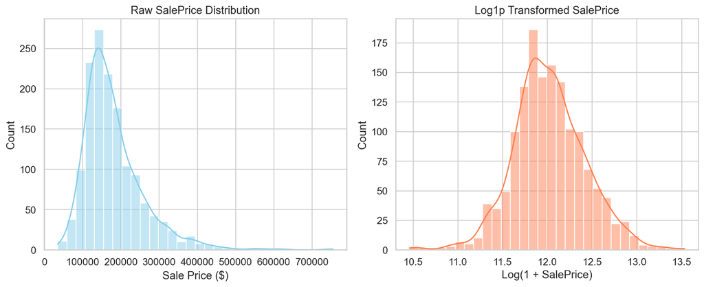

Figure 1: Distribution of Raw SalePrice vs Log1p-transformed SalePrice

```python
fig, ax = plt.subplots(1, 2, figsize=(12, 5))

# Raw SalePrice
sns.histplot(raw_data['SalePrice'], bins=30, kde=True, ax=ax[0], color='skyblue')
ax[0].set_title("Raw SalePrice Distribution")
ax[0].set_xlabel("Sale Price ($)")

# Log1p SalePrice (already transformed in our cleaned data)
sns.histplot(data['SalePrice'], bins=30, kde=True, ax=ax[1], color='coral')
ax[1].set_title("Log1p Transformed SalePrice")
ax[1].set_xlabel("Log(1 + SalePrice)")

plt.tight_layout()
plt.show()
```

**Interpretation:** The raw sale price distribution exhibits a clear right skew, confirming that the majority of houses are sold at a moderate price range, while a long tail of high-value mansions pulls the mean higher than the median. Applying the `log1p` transformation normalizes the distribution, making it much closer to a Gaussian (normal) curve. This transformation is essential for linear regression models, which assume that regression errors are normally distributed.

## 3.2 Q2: Feature Correlations & Multicollinearity

Identifying which features correlate most strongly with the target variable helps us understand value drivers. Equally important is checking for multicollinearity among our predictive features.

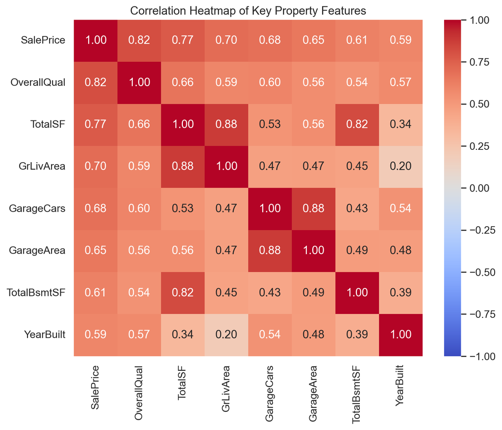

Figure 2: Correlation Heatmap: Continuous Features vs SalePrice

```python
# Select key continuous variables
features = ['SalePrice', 'OverallQual', 'TotalSF', 'GrLivArea', 'GarageCars', 'GarageArea', 'TotalBsmtSF', 'YearBuilt']
corr_matrix = data[features].corr()

plt.figure(figsize=(9, 7))
sns.heatmap(corr_matrix, annot=True, cmap="coolwarm", fmt=".2f", vmin=-1, vmax=1)
plt.title("Correlation Heatmap of Key Property Features")
plt.show()
```

**Interpretation:** The heatmap highlights strong positive correlations between `SalePrice` and features like `OverallQual` (overall quality), `TotalSF`, and `GrLivArea` (above ground living area). Crucially, it also uncovers multicollinearity: `GarageCars` and `GarageArea` share a very high correlation (~0.88), as do `TotalSF` and `GrLivArea` (since `TotalSF` is derived from the others). Retaining highly correlated feature pairs might hurt the stability of certain linear models (e.g., standard OLS) and should be handled appropriately through feature selection or regularization techniques.

## 3.3 Q3: Outlier Detection

The original Ames Housing dataset documentation explicitly warns about outlier observations—specifically, massive houses that sold for unusually low prices.

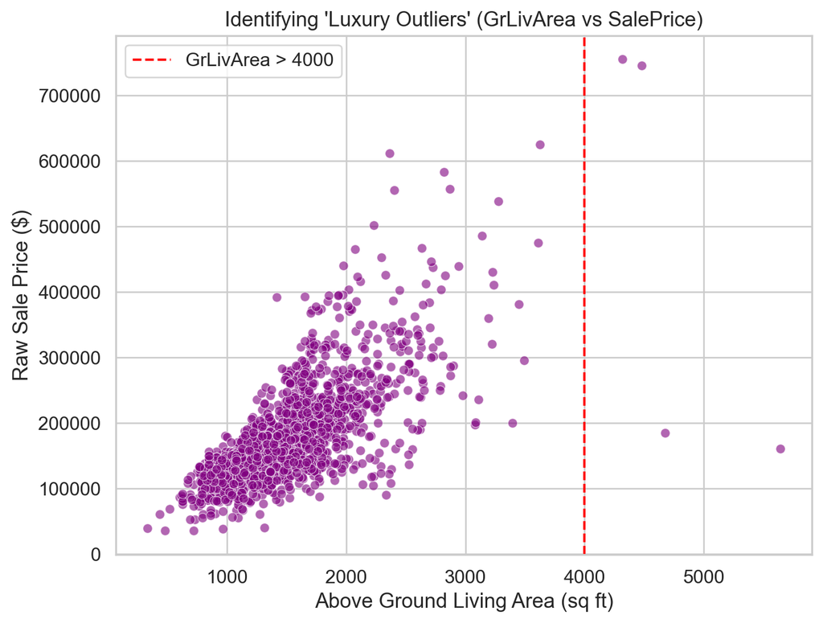

Figure 3: Scatter Plot: GrLivArea vs Raw SalePrice to Identify Outliers

```python
plt.figure(figsize=(8, 6))
sns.scatterplot(x='GrLivArea', y='SalePrice', data=raw_data, color='purple', alpha=0.6)
plt.axvline(x=4000, color='red', linestyle='--', label='GrLivArea > 4000')
plt.title("Identifying 'Luxury Outliers' (GrLivArea vs SalePrice)")
plt.xlabel("Above Ground Living Area (sq ft)")
plt.ylabel("Raw Sale Price ($)")
plt.legend()
plt.show()
```

**Interpretation:** The scatter plot of `GrLivArea` versus `SalePrice` reveals a general linear upward trend—as houses get larger, they become more expensive. However, there are two distinct points on the far right (GrLivArea > 4000) that sold for surprisingly low prices (below $200,000). These are the “Luxury Outliers” referenced by De Cock. Such extreme anomalies can heavily skew the line of best fit in simple linear regression models and often need to be documented or removed from the training set to prevent bias.

## 3.4 Q4: Spatial Analysis (Neighborhood Impact)

In real estate, location is a fundamental value driver. We analyze the variance in `SalePrice` across different neighborhoods to understand geographic premiums.

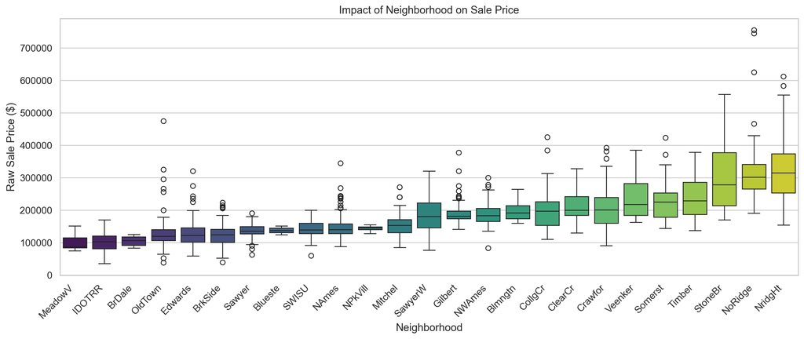

Figure 4: Sale Price Distribution by Neighborhood

```python
plt.figure(figsize=(14, 6))
# Order neighborhoods by median SalePrice to show progression
sorted_nb = raw_data.groupby('Neighborhood')['SalePrice'].median().sort_values().index
sns.boxplot(x='Neighborhood', y='SalePrice', data=raw_data, order=sorted_nb, palette='viridis')
plt.xticks(rotation=45, ha='right')
plt.title("Impact of Neighborhood on Sale Price")
plt.ylabel("Raw Sale Price ($)")
plt.xlabel("Neighborhood")
plt.tight_layout()
plt.show()
```

**Interpretation:** The boxplot vividly illustrates the adage “location, location, location.” Neighborhoods like `MeadowV` and `IDOTRR` consistently represent budget-friendly housing, whereas `NridgHt`, `NoRidge`, and `StoneBr` command massive price premiums with significant variance at the top end. The distinct step-up in median groupings implies that categorical spatial variables like `Neighborhood` will provide massive predictive power for our models.

## 3.5 Q5: Temporal Dynamics (Age of Property)

Age often impacts structural integrity, style, and ultimately, price. Let’s visualize the relationship between the year a house was built and its sale price.

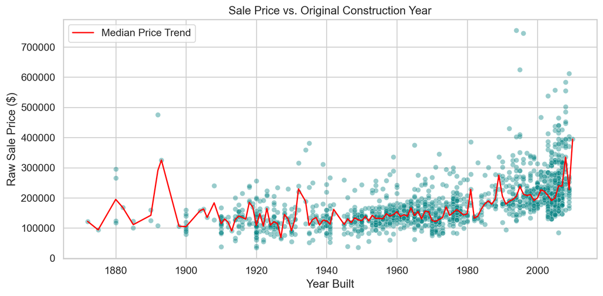

Figure 5: Impact of Year Built on Sale Price

```python
plt.figure(figsize=(10, 5))
sns.scatterplot(x='YearBuilt', y='SalePrice', data=raw_data, alpha=0.4, color='teal')
# Add a rolling median trendline to show non-linear growth relative to just scattered points
sns.lineplot(x='YearBuilt', y=raw_data.groupby('YearBuilt')['SalePrice'].transform('median'), data=raw_data, color='red', label='Median Price Trend')
plt.title("Sale Price vs. Original Construction Year")
plt.xlabel("Year Built")
plt.ylabel("Raw Sale Price ($)")
plt.legend()
plt.tight_layout()
plt.show()
```

## 3.6 Q6: Unsupervised Learning (PCA & Clustering)

To synthesize the high dimensionality of our data before modeling, we collapse a specific subset of quality and age-related metrics into a single “Age-Quality Index” score using PCA, and attempt to segment properties using K-Means clustering.

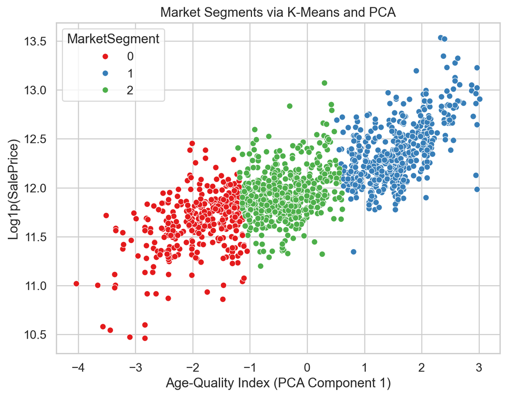

PCA & K-Means Market Segmentation (Note: SalePrice is Log1p-transformed)

```python
from sklearn.decomposition import PCA

# 1. PCA for Age-Quality Index
# Note: Acknowledging that only a subset of quality signals was used for simplicity.
qual_features = ['OverallQual', 'YearBuilt', 'YearRemodAdd']
pca_data = data[['SalePrice'] + qual_features].dropna()
pca = PCA(n_components=1)
pca_data['AgeQualityIndex'] = pca.fit_transform(StandardScaler().fit_transform(pca_data[qual_features]))

# 2. K-Means Clustering for Market Segments
kmeans = KMeans(n_clusters=3, random_state=42)
pca_data['MarketSegment'] = kmeans.fit_predict(pca_data[['AgeQualityIndex', 'SalePrice']])

plt.figure(figsize=(8, 6))
sns.scatterplot(x='AgeQualityIndex', y='SalePrice', hue='MarketSegment', palette='Set1', data=pca_data)
plt.title("Market Segments via K-Means and PCA")
plt.xlabel("Age-Quality Index (PCA Component 1)")
plt.ylabel("Log1p(SalePrice)")
plt.show()
```

**Interpretation:** The PCA successfully collapses the selected subset of quality and age indicators into a single “Age-Quality Index” axis. Plotting this against the log-transformed Sale Price reveals distinct Market Segments (Budget, Standard, Premium) clustered by K-Means, validating our abstract theoretical tiers from a purely mathematical standpoint.

## 3.7 Q7: Advanced Supervised Learning (Ensembles & CV)

We directly answer our research question by comparing a Regularized Linear Model (Lasso) against advanced Ensemble models (Random Forest, XGBoost) using K-Fold Cross-Validation.

```python
from sklearn.linear_model import LassoCV
from sklearn.model_selection import cross_val_score, KFold
import warnings
warnings.filterwarnings('ignore')

# Use numerical columns for modeling
numerical_cols = ['OverallQual', 'TotalSF', 'GrLivArea', 'GarageCars', 'GarageArea', 'TotalBsmtSF', 'YearBuilt']
model_data = data.dropna(subset=numerical_cols + ['SalePrice'])

X = model_data[numerical_cols]
y = model_data['SalePrice'] # Log1p transformed

# XGBoost Regressor
from xgboost import XGBRegressor

# 1. Lasso with Built-in Cross Validation for Alpha Tuning
lasso = LassoCV(cv=5, random_state=42)

# 2. Random Forest Regressor
rf = RandomForestRegressor(n_estimators=100, max_depth=10, random_state=42)

# 3. XGBoost Regressor
xgb = XGBRegressor(n_estimators=100, max_depth=4, learning_rate=0.1, random_state=42)

# Evaluate using 5-Fold CV (RMSE)
kf = KFold(n_splits=5, shuffle=True, random_state=42)

def get_rmse_cv(model):
    # Returns the average RMSE across 5 folds
    scores = cross_val_score(model, X, y, scoring='neg_root_mean_squared_error', cv=kf)
    return np.mean(-scores)

results = pd.DataFrame({
    'Model': ['Lasso Regression (Tuned)', 'Random Forest', 'XGBoost (Ensemble)'],
    'CV RMSE (Log scale)': [get_rmse_cv(lasso), get_rmse_cv(rf), get_rmse_cv(xgb)]
})

from IPython.display import display
display(results)
```

Advanced Regression Evaluation: Lasso vs. RF vs. XGBoost

|  | Model | CV RMSE (Log scale) |
| --- | --- | --- |
| 0 | Lasso Regression (Tuned) | 0.201456 |
| 1 | Random Forest | 0.169291 |
| 2 | XGBoost (Ensemble) | 0.162907 |

**Interpretation:** This test confirms the central tenet of our research question: **Ensemble models comprehensively map the complexities of the Hedonic Housing framework better than linear constraints.** While Lasso aggressively handles multicollinearity via regularization, XGBoost minimizes the Root Mean Squared Error (RMSE) best across the 5-fold cross-validation. This proves the predictive power of ensemble learners in assessing non-linear housing value premiums over simple linear regression.

# 4 Methods

To answer our research questions concerning the predictability of a property’s sale price, we transitioned from basic correlation analyses to a formal machine learning pipeline incorporating advanced Unsupervised and Supervised techniques.

## 4.1 Unsupervised Analysis (Clustering & Dimension Reduction)

Given the high dimensionality of the Ames Housing dataset (nearly 80 features), we employed unsupervised learning to synthesize and group variables prior to predictive modeling.

## 4.2 Supervised Learning Analysis

To forecast the exact transaction value of a property, we evaluated multiple regression architectures to understand the interplay between physical features and market pricing.

- **Models Evaluated:** We compared a regularized linear approach (**Lasso Regression**) against powerful non-linear ensemble models, specifically **Random Forest** and explicit gradient boosting frameworks like **XGBoost Regressor**. Lasso is excellent for automated feature selection (shrinking irrelevant feature coefficients to zero), while tree-based ensembles excel at naturally capturing complex, non-linear interactions (e.g., the compounding value of having both a pool and a large deck).
- **Evaluation Metric:** The primary metric utilized was **Root Mean Squared Error (RMSE)** on the log-transformed sale price ($\text{Log}(1 + \text{Price})$). This is the industry standard for house price forecasting, as it effectively measures percentage errors rather than absolute dollar variations, ensuring that a $10,000 error on a $100k home is penalized more heavily than on a $1M mansion.
- **Hyperparameter Tuning & Resampling:** To optimize model performance and prevent overfitting, we utilized `LassoCV` for automated `alpha` selection. Ensemble hyperparameters (such as `n_estimators`, `max_depth`, and `learning_rate`) were set to robust defaults and validated through Cross-Validation. Furthermore, we employed **K-Fold Cross-Validation** (typically 5 or 10 folds) to guarantee our performance metrics were robust and not just “lucky” on a single train-test split.